# An introduction to purrr and furrr

Laura J. Graham

19/01/2021

It’s easiest to install `purrr` as part of the `tidyverse`. `furrr` needs to be installed separately. For info, this is a paralellised version of `purrr`; more on this later. We are also going to use the `repurrrsive` package for data.

```r
# make sure these are all installed
library(tidyverse)
library(furrr)
library(repurrrsive)
library(magrittr)
library(broom)
library(furrr)
```

# Learning to map

The basic function of `purrr` is `map()`. This is very similar to the `apply()` family of functions.

A template for basic map() usage:

```
map(YOUR_LIST, YOUR_FUNCTION)
```

It works like this:

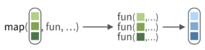

The function can be inbuilt, or user-defined.

We are going to use the Game of Thrones characters dataset from `repurrrsive`. Quick look at the data.

```r
length(got_chars)
```

```
## [1] 30
```

```r
names(got_chars[[1]])
```

```
##  [1] "url"         "id"          "name"        "gender"      "culture"
##  [6] "born"        "died"        "alive"       "titles"      "aliases"
## [11] "father"      "mother"      "spouse"      "allegiances" "books"
## [16] "povBooks"    "tvSeries"    "playedBy"
```

```r
got_chars[[1]]
```

```
## $url
## [1] "https://www.anapioficeandfire.com/api/characters/1022"
##
## $id
## [1] 1022
##
## $name
## [1] "Theon Greyjoy"
##
## $gender
## [1] "Male"
##
## $culture
## [1] "Ironborn"
##
## $born
## [1] "In 278 AC or 279 AC, at Pyke"
##
## $died
## [1] ""
##
## $alive
## [1] TRUE
##
## $titles
## [1] "Prince of Winterfell"
## [2] "Captain of Sea Bitch"
## [3] "Lord of the Iron Islands (by law of the green lands)"
##
## $aliases
## [1] "Prince of Fools" "Theon Turncloak" "Reek"            "Theon Kinslayer"
##
## $father
## [1] ""
##
## $mother
## [1] ""
##
## $spouse
## [1] ""
##
## $allegiances
## [1] "House Greyjoy of Pyke"
##
## $books
## [1] "A Game of Thrones" "A Storm of Swords" "A Feast for Crows"
##
## $povBooks
## [1] "A Clash of Kings"     "A Dance with Dragons"
##
## $tvSeries
## [1] "Season 1" "Season 2" "Season 3" "Season 4" "Season 5" "Season 6"
##
## $playedBy
## [1] "Alfie Allen"
```

Let’s use `map()` for element extraction. We can extract the name of all the characters in the dataset.

```r
map(got_chars, "name")
```

```
## [[1]]
## [1] "Theon Greyjoy"
##
## [[2]]
## [1] "Tyrion Lannister"
##
## [[3]]
## [1] "Victarion Greyjoy"
##
## [[4]]
## [1] "Will"
##
## [[5]]
## [1] "Areo Hotah"
##
## [[6]]
## [1] "Chett"
##
## [[7]]
## [1] "Cressen"
##
## [[8]]
## [1] "Arianne Martell"
##
## [[9]]
## [1] "Daenerys Targaryen"
##
## [[10]]
## [1] "Davos Seaworth"
##
## [[11]]
## [1] "Arya Stark"
##
## [[12]]
## [1] "Arys Oakheart"
##
## [[13]]
## [1] "Asha Greyjoy"
##
## [[14]]
```

[output cut: 34 more lines]

```
##
## [[26]]
## [1] "Melisandre"
##
## [[27]]
## [1] "Merrett Frey"
##
## [[28]]
## [1] "Quentyn Martell"
##
## [[29]]
## [1] "Samwell Tarly"
##
## [[30]]
## [1] "Sansa Stark"
```

As these are all character fields, we can use `map_chr()` to extract them as such.

```r
map_chr(got_chars, "name")
```

```
##  [1] "Theon Greyjoy"      "Tyrion Lannister"   "Victarion Greyjoy"
##  [4] "Will"               "Areo Hotah"         "Chett"
##  [7] "Cressen"            "Arianne Martell"    "Daenerys Targaryen"
## [10] "Davos Seaworth"     "Arya Stark"         "Arys Oakheart"
## [13] "Asha Greyjoy"       "Barristan Selmy"    "Varamyr"
## [16] "Brandon Stark"      "Brienne of Tarth"   "Catelyn Stark"
## [19] "Cersei Lannister"   "Eddard Stark"       "Jaime Lannister"
## [22] "Jon Connington"     "Jon Snow"           "Aeron Greyjoy"
## [25] "Kevan Lannister"    "Melisandre"         "Merrett Frey"
## [28] "Quentyn Martell"    "Samwell Tarly"      "Sansa Stark"
```

Notice instead of a list output, we get a character vector.

We can also output a dataframe, let’s output several attributes of the characters into a dataframe using `map_dfr()`. We can use the `extract()` function from `magrittr` to extract multiple elements.

```r
map_dfr(got_chars, extract, c("name", "culture", "gender", "id", "born", "alive"))
```

```
## # A tibble: 30 x 6
##    name            culture    gender    id born                            alive
##    <chr>           <chr>      <chr>  <int> <chr>                           <lgl>
##  1 Theon Greyjoy   "Ironborn" Male    1022 "In 278 AC or 279 AC, at Pyke"  TRUE
##  2 Tyrion Lannist~ ""         Male    1052 "In 273 AC, at Casterly Rock"   TRUE
##  3 Victarion Grey~ "Ironborn" Male    1074 "In 268 AC or before, at Pyke"  TRUE
##  4 Will            ""         Male    1109 ""                              FALSE
##  5 Areo Hotah      "Norvoshi" Male    1166 "In 257 AC or before, at Norvo~ TRUE
##  6 Chett           ""         Male    1267 "At Hag's Mire"                 FALSE
##  7 Cressen         ""         Male    1295 "In 219 AC or 220 AC"           FALSE
##  8 Arianne Martell "Dornish"  Female   130 "In 276 AC, at Sunspear"        TRUE
##  9 Daenerys Targa~ "Valyrian" Female  1303 "In 284 AC, at Dragonstone"     TRUE
## 10 Davos Seaworth  "Westeros" Male    1319 "In 260 AC or before, at King'~ TRUE
## # ... with 20 more rows
```

Here, we have passed in additional optional arguments. These are all other arguments passed into the function - in this case, the name of the elements to extract.

## Parallel map

The `map2()` and `pmap()` functions allow us to pass in two or more lists, respectively. I’ll give a quick example of `map2()` with a user-defined function.

First, extract names and birthplace information

```r
nms <- got_chars %>%
  map_chr("name")
birth <- got_chars %>%
  map_chr("born")
```

Then we can create a user-defined function which takes a name and birthplace as input, and outputs a string stating their name “was born” and birthplace.

```r
my_fun <- function(x, y) paste(x, "was born", y)
map2_chr(nms, birth, my_fun) %>% head()
```

```
## [1] "Theon Greyjoy was born In 278 AC or 279 AC, at Pyke"
## [2] "Tyrion Lannister was born In 273 AC, at Casterly Rock"
## [3] "Victarion Greyjoy was born In 268 AC or before, at Pyke"
## [4] "Will was born "
## [5] "Areo Hotah was born In 257 AC or before, at Norvos"
## [6] "Chett was born At Hag's Mire"
```

# A real example

Although these are helpful to understand the general concepts behind purrr, I never really saw it’s power until I started using it for performing the same analysis on multiple datasets.

Here is `purrr` being used in [my own paper](https://besjournals.onlinelibrary.wiley.com/doi/full/10.1002/pan3.10042). Full analysis details and code are available on [GitHub](https://github.com/laurajanegraham/recreation_scaling). In this, I aimed to understand drivers of outdoor recreation based on (1) multiple scales, and (2) multiple datasets. In total, I needed to perform the same analysis at 4 spatial resolutions on 2 datasets (a total of 8 analyses). Rather than write out the analysis 8 times, or do a for loop, what I’ve done is used `map()` to perform the analysis on all datasets simultaneously.

First, we need to know about nested datasets using `nest()`

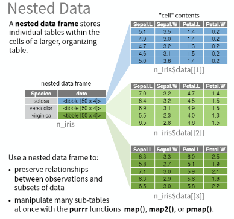

```r
load("data/rec_analysis_data.Rda")

head(df_analysis_n)
```

```
## # A tibble: 6 x 13
## # Groups:   resolution [1]
##   resolution      x      y dem_range  dist lcm_agri lcm_coast lcm_forest
##   <fct>       <dbl>  <dbl>     <dbl> <dbl>    <dbl>     <dbl>      <dbl>
## 1 5km        417500 632500    -0.373  1.91    1.37      0.619     -0.712
## 2 5km        387500 627500     2.02   1.99   -1.59     -0.208      0.756
## 3 5km        402500 627500     0.463  1.88    1.15     -0.208      0.120
## 4 5km        422500 627500    -1.13   1.81   -0.322     2.84      -1.00
## 5 5km        392500 617500     2.38   1.79   -1.64     -0.208     -0.871
## 6 5km        402500 617500     1.21   1.69    0.259    -0.208     -0.264
## # ... with 5 more variables: lcm_shei <dbl>, pa <dbl>, pop <dbl>,
## #   dataset <chr>, response <dbl>
```

```r
fit_mod_full <- function(dat) {
  glm(response ~
        lcm_agri +
        lcm_forest +
        lcm_coast +
        lcm_shei +
        dem_range +
        pa +
        pop +
        dist,
      family = poisson,
      data = dat)
}

calc_d2 <- function(x) {
   (x$null.deviance - x$deviance) / x$null.deviance
}
```

```r
mod <- df_analysis_n %>%
  group_by(resolution, dataset) %>%
  nest() %>%
  mutate(mod_full = map(data, fit_mod_full),
         mod_tidy = map(mod_full, tidy),
         mod_full_D2 = map_dbl(mod_full, calc_d2)
         )
```

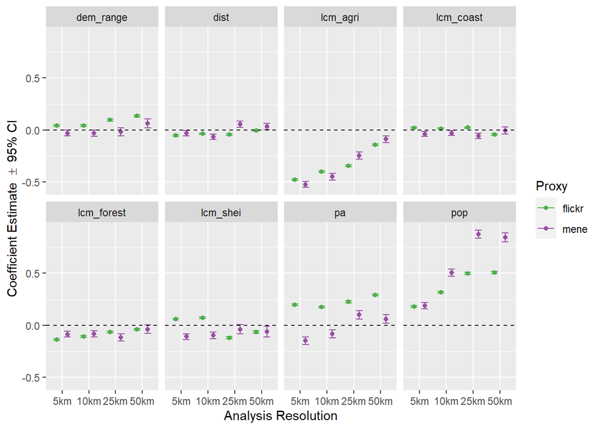

```r
mod_stats <- mod %>%
  select(resolution, dataset, mod_tidy) %>%
  unnest() %>%
  filter(term != "(Intercept)") %>%
  mutate(lci = estimate - 1.96*std.error,
         uci = estimate + 1.96*std.error) %>%
  select(resolution, dataset, var = term, coef = estimate, lci, uci)

ggplot(mod_stats, aes(x = resolution, y = coef, ymin = lci, ymax = uci, colour = dataset)) +
  geom_point(position = position_dodge(0.8)) +
  geom_errorbar(position = position_dodge(0.8), width = 0.5) +
  geom_hline(yintercept = 0, linetype = "dashed") +
  scale_colour_manual("Proxy", values = c("#4daf4a", "#984ea3")) +
  xlab("Analysis Resolution") + ylab(expression("Coefficient Estimate " %+-% " 95% CI")) +
  facet_wrap(~var, nrow = 2)
```

```r
mod_d2 <- mod %>%
  select(resolution, dataset, mod_full_D2)

knitr::kable(mod_d2, digits = 2)
```

| resolution | dataset | mod_full_D2 |
| --- | --- | --- |
| 5km | flickr | 0.34 |
| 10km | flickr | 0.48 |
| 25km | flickr | 0.62 |
| 50km | flickr | 0.65 |
| 5km | mene | 0.41 |
| 10km | mene | 0.58 |
| 25km | mene | 0.80 |
| 50km | mene | 0.94 |

# `furrr`

`furrr` allows us to run `purrr` functions in parallel - great for functions which take a while.

This is built upon the [`future` package](https://cran.r-project.org/web/packages/future/vignettes/future-1-overview.html).

First we have to set up a parallel session. In windows, this needs to be `plan(multisession)`. For mac or linux, `plan(multicore)` is more efficient.

```r
plan(multisession)
```

```r
mod_furrr <- df_analysis_n %>%
  group_by(resolution, dataset) %>%
  nest() %>%
  mutate(mod_full = future_map(data, fit_mod_full),
         mod_tidy = map(mod_full, tidy))
```

In this case, the overhead of setting up the paralell session makes this not worth it, but for more models to be fit, or for models or functions that take longer, it’s well worth it.

The `furrr` functions follow the same format as the `purrr` functions (e.g. `future_map_dfr`, `future_map_dbl`, `future_map_chr`, `future_map2` etc.).

# Further resources

- [`purrr` tutorial](https://jennybc.github.io/purrr-tutorial/)
- [`purrr` cheatsheet](https://github.com/rstudio/cheatsheets/blob/master/purrr.pdf)
- [`furrr` tutorial](http://zevross.com/blog/2019/02/12/dramatically-speed-up-your-r-purrr-functions-with-the-furrr-package/)